# Project:Brazil Medical Appointment No Show

### Research Question: Characteristics of Patients

#### Age Group

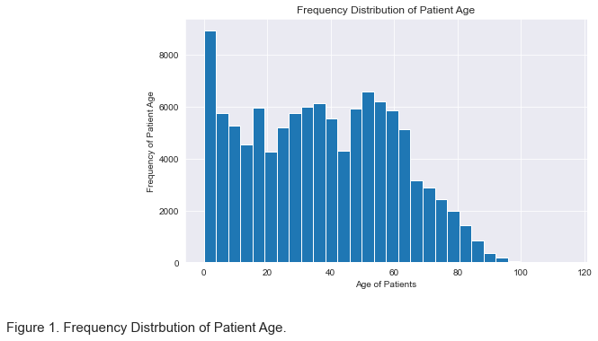

```python
# plotting a histogram

df_appointment["Age"].hist(bins= 30,figsize=(8,5))
plt.xlabel("Age of Patients")
plt.ylabel("Frequency of Patient Age")
plt.title("Frequency Distribution of Patient Age")

txt="Figure 1. Frequency Distrbution of Patient Age."
plt.figtext(0.05,-0.09, txt, wrap= True, horizontalalignment="center", fontsize= 15);
```

From Figure 1 above, the distribution of patient age is heavy-tailed and appears to be skewed to the right. Let's plot a Kernel density estimate of age of patients who did not show up and patients who did.

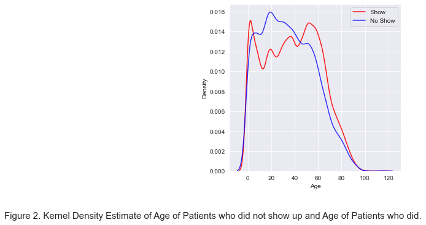

```python
# defining figure parameter
rcParams["figure.figsize"]=5,5
# kde plot for patients who showed up
sns.kdeplot(show["Age"],color="red",alpha = 0.9,label= "Show")

# kde plot for age of patients who didn't show
sns.kdeplot(no_show["Age"],color="blue",alpha=0.8, label= "No Show")

plt.legend()

txt="Figure 2. Kernel Density Estimate of Age of Patients who did not show up and Age of Patients who did."
plt.figtext(0.05,-0.09, txt, wrap= True, horizontalalignment="center", fontsize= 15);
```

Based on Figure 2, the rate of no showing up for appointment increased in patients with age between 20years and 40years.

```python
df_appointment["Age"].describe()
```

```
count    110521.000000
mean         37.089386
std          23.109885
min           0.000000
25%          18.000000
50%          37.000000
75%          55.000000
max         115.000000
Name: Age, dtype: float64
```

To explore more of the age of patients, let's group the age and create a new column for it called Age_group.

```python
def proportion_countplot(col,data):
    """ This function counts the frequency of unique values in columns, and plots a countplot with its proportions"""
    # counts the frequency of unique values
    group_count=data[col].value_counts()
    # get the unique values in column,in order of decreasing frequency
    order= group_count.index
    # creating a base color for countplot
    base_color=sns.color_palette()[0]

    # returns the of all the non-null values in the column
    count_sum= data[col].value_counts().sum()


    # plotting sns countplot
    sns.countplot(y=col ,data=data,color=base_color,order=order)

    # Getting Proportions
    for i in range(group_count.shape[0]):
        counts=group_count[i]
        pct_string="{:0.1f}%".format(100*counts/count_sum)
        plt.text(counts + 1, i, pct_string, va="center",color="red")
```

```python
def groupby_count(key1,key2,data):
    """ This functiongroups a dataframe by key1 and takes the value count fo key2  """

    val_count= data.groupby(key1)[key2].value_counts()
    return val_count
```

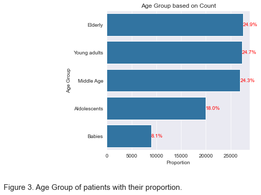

```python
proportion_countplot("Age_group",df_appointment)

plt.xlabel("Proportion")
plt.ylabel("Age Group")
plt.title("Age Group based on Count")
txt="Figure 3. Age Group of patients with their proportion."
plt.figtext(0.05,-0.09, txt, wrap= True, horizontalalignment="center", fontsize= 15);
```

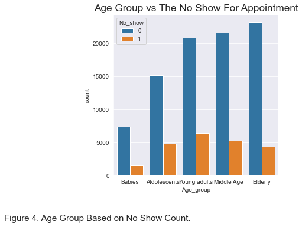

```python
# using a countplot
sns.countplot(hue="No_show",x="Age_group",data=df_appointment)
plt.title("Age Group vs The No Show For Appointment",fontsize="xx-large")

txt="Figure 4. Age Group Based on No Show Count."
plt.figtext(0.05,-0.09, txt, wrap= True, horizontalalignment="center", fontsize= 15);
```

Figure 4 shows the Age groups with the counts of show and no show. The Elderly age group highest count for showing up and the second to the last count for not showing up. Young Adults records the highest count for not showing up and this age group is the second largest total count. Let"s explore gender with age group

```python
# groupby and count
age_gender_count=groupby_count(["Age_group","Gender"],"No_show",df_appointment)
age_gender_count
```

```
Age_group     Gender  No_show
Babies        F       0           3555
                      1            775
              M       0           3805
                      1            808
Aldolescents  F       0           8089
                      1           2535
              M       0           7070
                      1           2228
Young adults  F       0          15154
                      1           4666
              M       0           5682
                      1           1746
Middle Age    F       0          14867
                      1           3637
              M       0           6784
                      1           1617
Elderly       F       0          15580
                      1           2978
              M       0           7621
                      1           1324
Name: No_show, dtype: int64
```

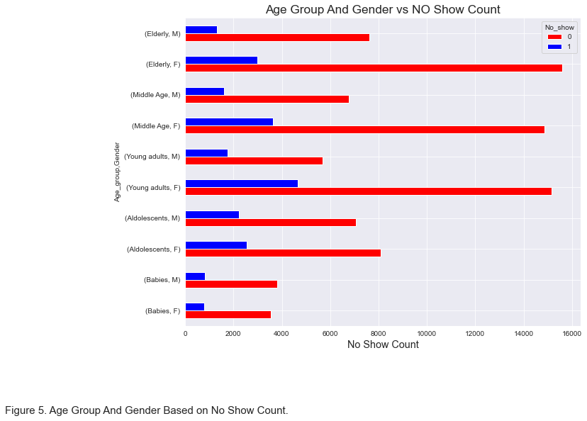

```python
age_gender_count.unstack().plot(kind="barh",color=["red","blue"],legend=True,figsize=(10,8))
plt.xlabel("No Show Count",fontsize="x-large")
plt.title("Age Group And Gender vs NO Show Count",fontsize="xx-large")

txt="Figure 5. Age Group And Gender Based on No Show Count."
plt.figtext(0.05,-0.09, txt, wrap= True, horizontalalignment="center", fontsize= 15);
```

The disparity in gender is low in babies with male having more counts than females and the no show count are higher in males. This disparity has huge increase in "Young Adults" the age group with the largest count of not showing with female higher than Male.

#### Illness And Scholarship

```python
# count of no show based on illness and scholarship
new_column=["Hypertension","Diabetes","Alcoholism","Handicap","Scholarship"]
for i in new_column:
    count = df_appointment[i].value_counts()
    print(count)
```

```
0    88720
1    21801
Name: Hypertension, dtype: int64
0    102578
1      7943
Name: Diabetes, dtype: int64
0    107161
1      3360
Name: Alcoholism, dtype: int64
0    108282
1      2239
Name: Handicap, dtype: int64
0    99660
1    10861
Name: Scholarship, dtype: int64
```

Based on the value counts, more patients have hypertension compared to other illness having a value of 21801. 10861 patients are receipient of scholarship.

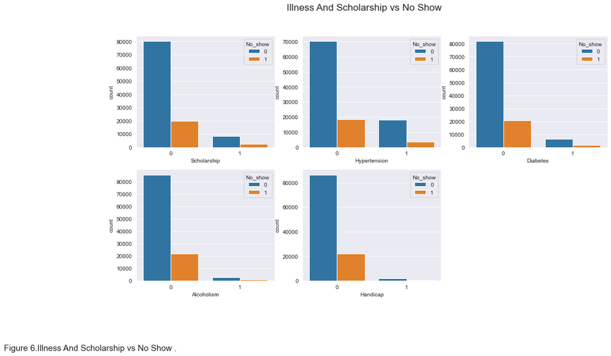

```python
# plotting illness and scholarship based on no show count
fig= plt.figure(figsize =(15,8))

ax1=fig.add_subplot(2,3,1)
sns.countplot(hue="No_show",x="Scholarship",data=df_appointment,ax=ax1)

ax2 = fig.add_subplot(2,3,2)
sns.countplot(hue="No_show",x="Hypertension",data=df_appointment,ax=ax2)

ax3 = fig.add_subplot(2,3,3)
sns.countplot(hue="No_show",x="Diabetes",data=df_appointment,ax=ax3)

ax4= fig.add_subplot(2,3,4)
sns.countplot(hue="No_show",x="Alcoholism",data=df_appointment,ax=ax4)

ax5 = fig.add_subplot(2,3,5)
sns.countplot(hue="No_show",x="Handicap",data=df_appointment, ax=ax5);

fig.suptitle("Illness And Scholarship vs No Show",fontsize="xx-large")

txt="Figure 6.Illness And Scholarship vs No Show ."
plt.figtext(0.05,-0.09, txt, wrap= True, horizontalalignment="center", fontsize= 15)
```

```python
# count of no show based on illness and scholarship
new_column=["Hypertension","Diabetes","Alcoholism","Handicap","Scholarship"]
for i in new_column:
    table=pd.pivot_table(no_show, index= i,columns="Age_group",values="No_show",
                              aggfunc="count")

    print(table)
```

```
Age_group     Babies  Aldolescents  Young adults  Middle Age  Elderly
Hypertension
0               1583          4750          6172        4067     1970
1                  0            13           240        1187     2332
Age_group  Babies  Aldolescents  Young adults  Middle Age  Elderly
Diabetes
0            1582          4748          6329        4862     3363
1               1            15            83         392      939
Age_group   Babies  Aldolescents  Young adults  Middle Age  Elderly
Alcoholism
0             1583          4751          6262        4915     4126
1                0            12           150         339      176
Age_group  Babies  Aldolescents  Young adults  Middle Age  Elderly
Handicap
0            1583          4687          6343        5149     4147
1               0            76            69         105      155
Age_group    Babies  Aldolescents  Young adults  Middle Age  Elderly
Scholarship
0              1525          4039          5463        4581     4128
1                58           724           949         673      174
```

Hypertension has the highest count of all illness and it's Elderly age group recorded 2332 of patients having hypertension not showing up while 1970 patients who did not have hypertension also did not show up.